# Pythonによるデモ

## 準備

### ダウンロード

リポジトリのページの "Code" --> "Download ZIP" から圧縮ファイルをダウンロードし、それを解凍する。あるいは、`git clone https://github.com/Wandao123/ising_model.git` コマンドを実行する。

### Vanilla Python

Pythonの処理系は[Windows Store](https://www.microsoft.com/ja-jp/p/python-38/9mssztt1n39l?activetab=pivot:overviewtab)や[公式ページ](https://www.python.org/)からダウンロード・インストールできる。ここでは仮想環境を作成し、そこへpipを用いて必要なライブラリをインストールする。PowerShellあるいはコマンドプロンプトを起動した上で、次のコマンドを実行する。

```
PS> cd ダウンロードしたフォルダ
PS> cd python
PS> python -m venv env
PS> env/Scripts/activate
PS> pip install numpy matplotlib multiprocess jupyterlab
```

### Anaconda

一般的な用途ではなく、データ分析や機械学習などに特化してPythonを用いる場合は[Anaconda](https://www.anaconda.com/)を利用する方法もある。Anacondaを利用する場合、必要なライブラリが既にインストールされている筈なので、前節の手順はほぼ不要である。しかしながら、独自ライブラリのインストールの関係上、仮想環境の作成は勧める。Anaconda PowerShell Promptを起動して、次を実行する。

```
PS> conda create -n ising_model
PS> conda activate ising_model
PS> conda install pip
PS> conda install jupyterlab  # Jupyter Labを使う場合。
```

### C++拡張ライブラリのインストール

```
PS> cd wheelパッケージをダウンロードしたフォルダ
PS> pip install simulatorWithCpp-*-*-*-*.whl
```

ただし、* の部分には適当なバージョン名やアーキテクチャ名が入る。

## デモンストレーション

必要なライブラリの読み込みを行う。Pythonのみで書かれたライブラリとC++拡張ライブラリとを切り替えるには、使いたい方のコメントアウトを解除し、他方をコメントアウトすればよい。それぞれについて、下記のコードを全く変えることがなく実行できることに注意。

```python
%matplotlib inline
import matplotlib.pyplot as plt
import numpy as np
import sys
sys.path.append('../python')
import simulator                      # Pythonのライブラリを使う場合。
#import simulatorWithCpp as simulator  # C++拡張ライブラリを使う場合。
```

### 頂点と辺の指定方法

```python
isingModel = simulator.IsingModel({'a': 1.e0, 'b': 2.e0}, {('a', 'b'): -3.e0})
isingModel.Write()
print()
print(isingModel.Spins)
```

```
Current spin configuration:
[1 1]

External magnetic field:
[1. 2.]
Coupling coefficinets:
[[ 0. -3.]
 [-3.  0.]]
Algorithm: Metropolis method

{'a': 1, 'b': 1}
```

一般に、Hamiltonian関数が $$ H(\sigma) = -\sum_{\{x, y\}\in E}J_{x, y} \sigma_x \sigma_y - \sum_{x\in V} h_x \sigma_x $$ と表されているとする。このシミュレーターでは、IsingModelクラスに外部磁場の強さ $\{h_x\}_{x\in V}$ とスピン-スピン結合係数 $\{J_{x, y}\}_{\{x,y\}\in E}$ とをPythonの辞書型変数の形式で渡す。外部磁場の強さは文字列あるいは整数をキーとする辞書である。また、スピン-スピン結合係数は文字列あるいは整数のタプルをキーとする辞書である。このタプルの要素は2つのみであり、かつ `(a, b)` に対して `a < b` でなければならない（然らざる場合は無視される）。何も指定しないときにはそこでの外部磁場の強さやスピン-スピン結合係数が $0$ であるものと解釈される。特に、空の辞書 `{}` を渡した場合は全ての頂点あるいは辺で $0$ になる。

**例** (Erdős-Rényiランダムグラフ) 辺の生成をプログラムに任せることで、ランダムグラフやスピングラスが生成できる。実行する度にスピン-スピン結合係数の行列が変化することを確認してみよ。

```python
maxNodes = 8
probability = 0.5e0
quadratic = {(i, j): -1 if np.random.random() <= probability else 0 for i in range(maxNodes) for j in range(i + 1, maxNodes)}
isingModel = simulator.IsingModel({}, quadratic)
isingModel.Write()
```

```
Current spin configuration:
[1 1 1 1 1 1 1 1]

External magnetic field:
[0. 0. 0. 0. 0. 0. 0. 0.]
Coupling coefficinets:
[[ 0. -1. -1.  0. -1.  0. -1. -1.]
 [-1.  0.  0. -1. -1.  0. -1. -1.]
 [-1.  0.  0. -1.  0.  0. -1. -1.]
 [ 0. -1. -1.  0. -1. -1.  0. -1.]
 [-1. -1.  0. -1.  0. -1. -1.  0.]
 [ 0.  0.  0. -1. -1.  0. -1.  0.]
 [-1. -1. -1.  0. -1. -1.  0.  0.]
 [-1. -1. -1. -1.  0.  0.  0.  0.]]
Algorithm: Metropolis method
```

### Glauber力学によるアニーリング

`IsingModel` クラスは `Temperature` プロパティを持つ。その値に応じて、`Update` メソッドによるスピンの更新確率が変化する。ここでは、更新アルゴリズムにGlauber力学を指定した上で、各モンテカルロ・ステップ $n$ で温度を下げてゆく。アニーリング・スケジュールには $$ T_n = \frac{T_0}{2 \log (n + 1) + 1}, \quad T_0 = 12 $$ を用いる。
※C++拡張ライブラリを用いているときはbad allocation errorが発生することがある。その場合は上記の「必要なライブラリの読み込み」のセルを選択した上で "Run" --> "Run Selected Cell and All Below" をクリックする。

```python
# 初期化。
isingModel = simulator.IsingModel({0: 1.e0, 1: 2.e0}, {(0, 1): -3.e0})
isingModel.Algorithm = simulator.Algorithms.Glauber  # 更新アルゴリズムを指定。
isingModel.Write()
print()
T0 = 12.e0
isingModel.Temperature = T0  # 温度の設定。

# サンプリング。
#samples = np.empty((0, 3), dtype=np.float)  # Numpyを使う場合。若干複雑になるので、最後にPythonのリストを変換する方法も併記している。
samples = []
for n in range(5000 * 2):
    isingModel.Temperature = T0 / (2 * np.log(1 + n) + 1.e0)
    isingModel.Update()
    #samples = np.append(samples, np.array([n, isingModel.Energy, isingModel.Temperature], dtype=np.float).reshape((1, 3)), axis=0)
    samples.append([n, isingModel.Energy, isingModel.Temperature])

# データの表示。
np.set_printoptions(threshold=30)  # 6行のみ表示。
output = np.array(samples, dtype=np.float)
print(output)
print()
print('The final configuration: {}'.format(isingModel.Spins))
```

```
Current spin configuration:
[1 1]

External magnetic field:
[1. 2.]
Coupling coefficinets:
[[ 0. -3.]
 [-3.  0.]]
Algorithm: Glauber dynamics

[[ 0.00000000e+00 -2.00000000e+00  1.20000000e+01]
 [ 1.00000000e+00  0.00000000e+00  5.02871741e+00]
 [ 2.00000000e+00  0.00000000e+00  3.75325527e+00]
 ...
 [ 9.99700000e+03 -4.00000000e+00  6.17910739e-01]
 [ 9.99800000e+03 -4.00000000e+00  6.17904374e-01]
 [ 9.99900000e+03 -4.00000000e+00  6.17898011e-01]]

The final configuration: {0: -1, 1: 1}
```

最後に出力されたデータの各列はそれぞれ、ステップ数、エネルギー、温度を表す。横軸をステップ数、縦軸をエネルギーとすると、次のグラフを得る。

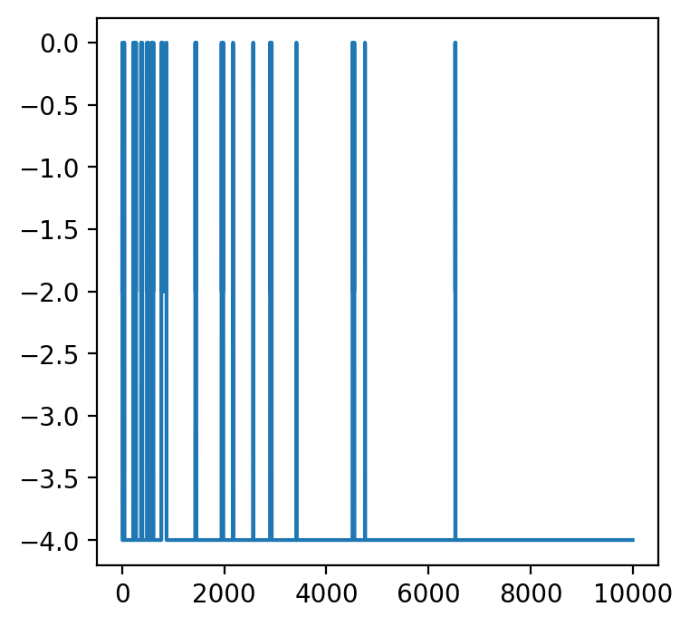

```python
x = output[:, 0]  # 0列目を抽出。
y = output[:, 1]

fig = plt.figure(figsize=(4, 4), dpi=200)
ax = fig.add_subplot(111)
ax.plot(x, y)
plt.show()
```

また、次はエネルギーについてヒストグラムを描いたものである。

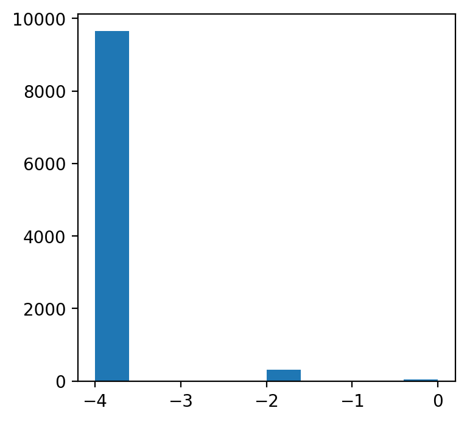

```python
fig = plt.figure(figsize=(4, 4), dpi=200)
ax = fig.add_subplot(111)
ax.hist(output[:, 1])
plt.show()
```

### SCAによるアニーリング

同様のことをSCAで行うと次のようになる。最大ステップ数を半分にしていることに注目。

```
[[ 0.00000000e+00  6.00000000e+00  1.20000000e+01]
 [ 1.00000000e+00  6.00000000e+00  5.02871741e+00]
 [ 2.00000000e+00 -4.00000000e+00  3.75325527e+00]
 ...
 [ 4.99700000e+03 -4.00000000e+00  6.65425049e-01]
 [ 4.99800000e+03 -4.00000000e+00  6.65410285e-01]
 [ 4.99900000e+03 -4.00000000e+00  6.65395525e-01]]
```

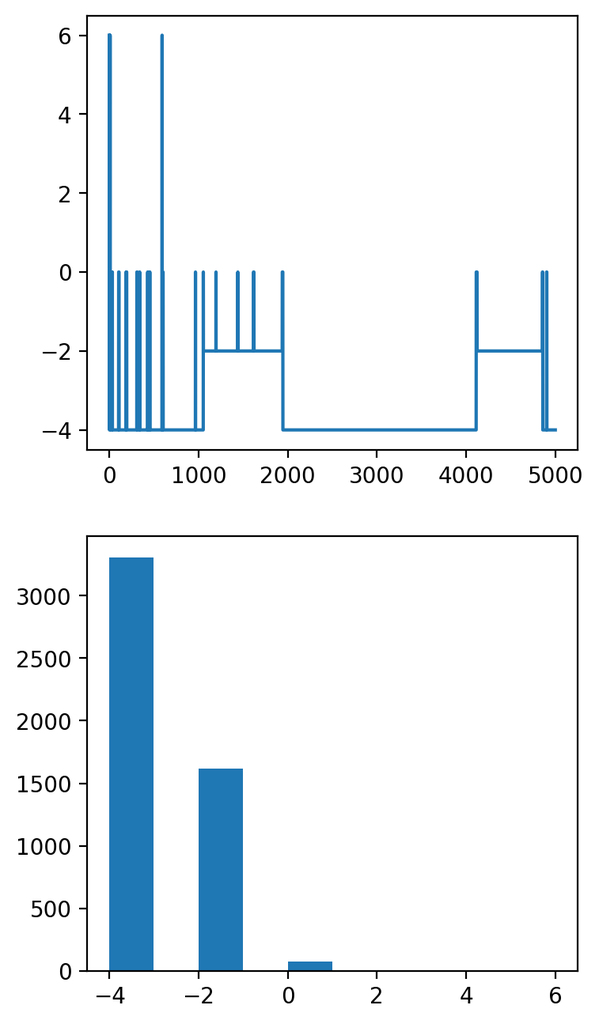

```python
# 初期化。
isingModel.Algorithm = simulator.Algorithms.SCA
isingModel.Temperature = T0
isingModel.PinningParameter = 3

# サンプリング。
samples = np.empty((0, 3), dtype=np.float)
for n in range(5000):
    isingModel.Temperature = T0 / (2 * np.log(1 + n) + 1.e0)
    isingModel.Update()
    samples = np.append(samples, np.array([n, isingModel.Energy, isingModel.Temperature], dtype=np.float).reshape((1, 3)), axis=0)

# データの表示。
np.set_printoptions(threshold=30)  # 6行のみ表示。
print(samples)

# グラフの描画。
fig = plt.figure(figsize=(4, 8), dpi=200)
ax = fig.add_subplot(211)
ax.plot(samples[:, 0], samples[:, 1])
ax = fig.add_subplot(212)
ax.hist(samples[:, 1])
plt.show()
```